# Disproportionality analysis

# Introduction

During the life cycle of a medicinal product, knowledge of the safety profile continues to accumulate post market introduction. Adverse event reports collected through spontaneous reporting play an instrumental part in this development.

Adverse event report databases often cover a wide range of drugs and events, beyond what can be feasibly monitored through manual work. Disproportionality analysis is thus often used to highlight drug-event-combinations of potential interest for further qualitative manual case-by-case assessment.

The `pvda` package provides three disproportionality estimators: the proportional reporting rate (PRR), the reporting odds ratio (ROR) and the information component (IC). It takes report level data as input, and outputs estimates for each drug-event-combination, possibly stratified by some variable of interest, e.g. age group and/or sex.

# Executing a disproportionality analysis

The workhorse of this package is the function `da`. The `da`-function takes patient level data in a data frame as input (here `drug_event_df`) and produces estimates and summary counts as demonstrated below.

```r
da_1 <-
  drug_event_df |>
  da()
```

The `drug_event_df` is a simulated data set with drugs named Drug_A - Drug_Z and events Event_1 - Event_1000. Further details about the simulation are documented in the data object (execute `?df_drug_event`).

## Specifying the column names

The da-function will examine the passed data set for column names contained in the passed parameter list “df_colnames”. The default column names are “report_id”, “drug” and “event”. If we rename the report-id column in “drug_event_df” we need to specify the new name in the call to da, as shown below:

```r
da_1 <-
  drug_event_df |>
  dplyr::rename(reportID = report_id) |>
  da(df_colnames = list(report_id = "reportID"))
```

## Summarizing and printing results

The ‘da_1’ object can then be passed to a summary and a print function.

```r
summary(da_1)
```

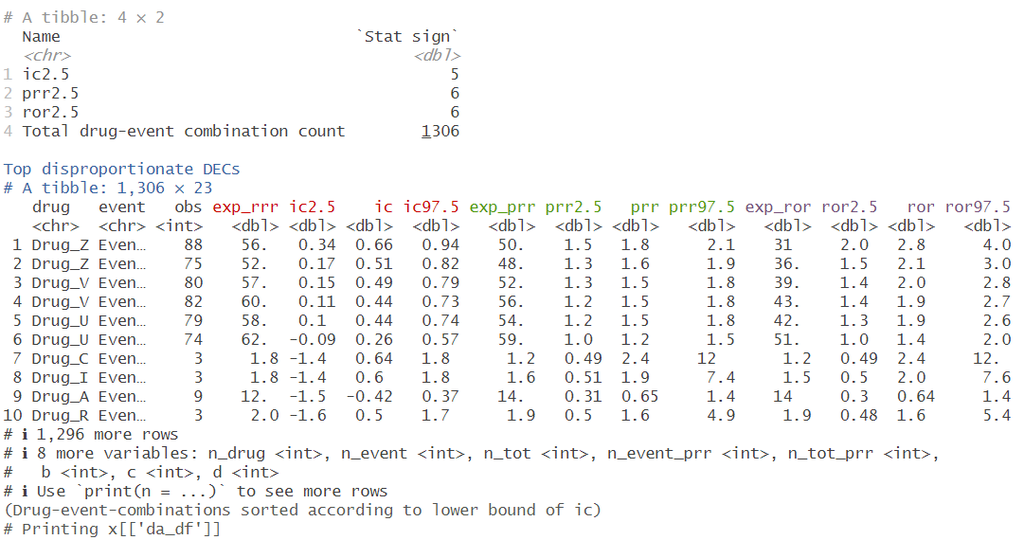

```r
print(da_1, n=3)
```

[figure not shown]

(Technical note: As printing of colors in the console is not easily reproduced within this vignette , we provide screenshots when applicable. )

## Passing correctly structured input data

The input data needs to be in a report-level format. every line in the data frame corresponds to a drug-event pair from a specific report.

```r
drug_event_df[1:6, ]
```

```
## # A tibble: 6 × 4
##   report_id drug   event    group
##       <int> <chr>  <chr>    <dbl>
## 1         1 Drug_A Event_23     1
## 2         1 Drug_D Event_6      1
## 3         1 Drug_E Event_8      1
## 4         1 Drug_I Event_9      1
## 5         2 Drug_B Event_2      0
## 6         2 Drug_G Event_13     0
```

## Extracting the results

For covenience, the output object of da is a list of class “da” containing two objects, the results (“da_df”) and the input parameters (“input_params”). At some point you might want to extract the results or the input parameters list, here we demonstrate some alternatives:

```r
names(da_1)
```

```
## [1] "da_df"        "input_params"
```

```r
# Different ways of extracting the results data frame
# da_1$da_df
# da_1[['da_df']]
# da_1 |> purrr::pluck("da_df")
```

## How to run a subgroup analysis?

The `da` function builds a comparator from the passed data, e.g. for `prr` by excluding the drug of interest from the comparator, sometimes referred to as the background. This implies that any subgroup analysis of e.g. specific age groups can be achieved by creating a new data frame with the subgroup of interest, and then passing it to `da`.

If a more exhaustive grouping is required, one can provide a grouping variable `group_by` to `da`. This executes a call to `da` for each grouping and return the results as a single data frame. The grouping could for instance be age groups, sex, countries, regions or a combination thereof, but needs to be passed as a single variable (character or numeric).

The drug_event_df contains two groups, in the column named “group”. We can pass “group” as the `group_by` parameter in `df_colnames` as below.

```r
drug_event_df |>
  head()
```

```
## # A tibble: 6 × 4
##   report_id drug   event    group
##       <int> <chr>  <chr>    <dbl>
## 1         1 Drug_A Event_23     1
## 2         1 Drug_D Event_6      1
## 3         1 Drug_E Event_8      1
## 4         1 Drug_I Event_9      1
## 5         2 Drug_B Event_2      0
## 6         2 Drug_G Event_13     0
```

```r
da_grouped <-
  drug_event_df |>
  da(df_colnames = list(group_by="group"))

print(da_grouped$da_df)
```

```
## # A tibble: 1,808 × 24
##    drug   event   group   obs exp_rrr ic2.5    ic ic97.5 exp_prr prr2.5   prr
##    <chr>  <chr>   <dbl> <int>   <dbl> <dbl> <dbl>  <dbl>   <dbl>  <dbl> <dbl>
##  1 Drug_Z Event_1     0    45    26.5  0.3   0.75   1.14    23.4   1.54  1.92
##  2 Drug_Z Event_1     1    43    29.1  0.09  0.56   0.96    26.5   1.28  1.63
##  3 Drug_Z Event_2     0    33    24.6 -0.12  0.42   0.87    23.2   1.07  1.42
##  4 Drug_Z Event_2     1    42    27.8  0.12  0.59   0.99    25.1   1.3   1.67
##  5 Drug_V Event_2     0    34    26.0 -0.14  0.38   0.82    24.6   1.04  1.38
##  6 Drug_V Event_2     1    46    31.0  0.12  0.56   0.95    27.8   1.3   1.66
##  7 Drug_V Event_1     0    40    28.0  0.03  0.51   0.92    25.8   1.21  1.55
##  8 Drug_V Event_1     1    42    32.4 -0.1   0.37   0.77    30.3   1.07  1.38
##  9 Drug_U Event_2     0    42    31.5 -0.06  0.41   0.81    29.1   1.11  1.44
## 10 Drug_U Event_2     1    37    26.8 -0.04  0.46   0.89    24.9   1.14  1.49
## # ℹ 1,798 more rows
## # ℹ 13 more variables: prr97.5 <dbl>, exp_ror <dbl>, ror2.5 <dbl>, ror <dbl>,
## #   ror97.5 <dbl>, n_drug <int>, n_event <int>, n_tot <int>, n_event_prr <int>,
## #   n_tot_prr <int>, b <int>, c <int>, d <int>
```

In the output we note the third column is “group”, i.e. the column name we passed. We also note that the drug-event-pairs are kept together, e.g. first and second row contains the same drug-event-combination, “Drug_Z” and “Event_1”. This is to simplify comparisons within a drug-event-pair across different groups, e.g. if the same pattern is seen across both males and females. The ordering of the drug-events in the output is made by averaging the selected disproportionality estimate (parameter `sort_by`), i.e. the top two rows have the highest average “ic2.5”.

# Frequently Asked Questions

## How are drug-event pairs occurring several times in one report counted?

If the same drug-event pair occurs several times in one report, these contributes to counts only once. That is, an observed count of five means that there were five different reports containing the drug-event-pair (at least once). It cannot be due to a single report containing the same drug-event pair five times due to repeated events or data quality issues. This is demonstrated below, where we duplicate the first row of drug_event_df and still arrive at an observed count of 1.

```r
first_row <- drug_event_df[1,]

first_row |>
  dplyr::bind_rows(first_row) |>
  da() |>
  purrr::pluck("da_df") |>
  dplyr::pull(obs)
```

```
## [1] 1
```

## How is the expected calculated?

Detailed formulas for PRR, RRR and IC are documented within each function ( “?prr”, “?rrr”, “?ic”), but overall one can note that all expected counts are derived from the same contingency table of those who were and were not exposed to the drug, and did and did not experience the adverse event. The sample used for the contingency table is the data frame passed to the da function. See also the grouping parameter.

```r
# Note the fourth column name:
drug_event_df |>
  da() |>
  purrr::pluck("da_df") |>
  dplyr::select(drug:ic97.5) |>
  print(n=1)
```

```
## # A tibble: 1,306 × 7
##   drug   event     obs exp_rrr ic2.5    ic ic97.5
##   <chr>  <chr>   <int>   <dbl> <dbl> <dbl>  <dbl>
## 1 Drug_Z Event_1    88    55.6  0.34  0.66   0.94
## # ℹ 1,305 more rows
```

## Rule of N

The function `da` has several input parameters. One is the `rule_of_N`, by default set to 3, which is sometimes referred to as “rule of three”. This sets ROR and PRR-values to NA if the observed count is less than the specified N. For completeness, note that the default shrinkage in the IC acts as a built in ‘rule of 3’, (i.e. the shrinkage of +0.5 prevents the lower bound to exceed 0 at the default significance level of 95%).

## Controlling the number of digits

The function `da` has a parameter `number_of_digits` controls the rounding of non-count values in the output, including all expected counts, uncertainty bounds and point estimates.

```r
drug_event_df |>
  da(
    rule_of_N = 3,
    number_of_digits = 8
  ) |> print(n = 3)
```

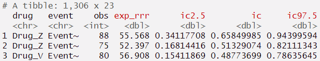

## Can I use pvda to get IC, PRR or ROR, when I already have the observed and expected counts?

Yes, you can calculate point estimates with confidence or credibility intervals for specific drug-event-combination if you already have the number of observed reports, and other required counts such as the database total count, number of reports with the exposure and number of reports with the event. This can be helpful for instance to quality check results, e.g. from papers or other software.

```r
prr(obs = 10, n_drug = 1000, n_event_prr = 200, n_tot_prr = 10000)
```

```
## # A tibble: 1 × 3
##   prr2.5   prr prr97.5
##    <dbl> <dbl>   <dbl>
## 1  0.266   0.5   0.940
```

```r
ror(a = 10, b = 20, c = 200, d = 10000)
```

```
## # A tibble: 1 × 3
##   ror2.5   ror ror97.5
##    <dbl> <dbl>   <dbl>
## 1   11.6    25    54.1
```

```r
ic(obs = 10, exp = 5)
```

```
## # A tibble: 1 × 3
##     ic2.5    ic ic97.5
##     <dbl> <dbl>  <dbl>
## 1 -0.0973 0.933   1.69
```

For further details on the specific input parameters, consult the documentation of each function.

## How fast is pvda?

The data.table-package (through “dtplyr”) is used for fast execution. A test of the execution speed was made using the `vaers` R package, available on [gitlab](https://gitlab.com/iembry/vaers.git). The `vaers` package contains data from VAERS from years 1990 - 2018, resulting in 4 146 778 rows to be processed by `da` in `pvda`. Execution time on a regular laptop was less than 10 seconds.